# Bermuda Atlantic Time Series-Ocean acidification

Leira J. Centeno

2022-04-25

**Introduction**

Bermuda is an archipelago island located in the western North Atlantic Ocean compound of seven main islands and one hundred seventy islets (Rushe, G. et al., 2021). The Bermuda Institute of Ocean Science (BIOS) is located at the east end of the Island in the Ferry Reach, St. George’s. Bermuda Biological Station for Research (BBSR) it’s been there since 1932. Since 1991 Bermuda Atlantic Time Series-Ocean acidification (BATS) provides data sets in the world acquiring measurements of some parameters such as salinity, temperature, carbon dioxide, density, pressure and oxygen. The importance of the selected surface parameters is to follow the levels of the ocean acidification research. This report is going to present if surface water parameters are increasing or decreasing. With BATS measurements of alcalinity we could calculated others parameters like disolved inorganic carbon, pCO2, pH, omega. The worked data was provided by the BIOS **[website](http://bats.bios.edu/)**.

## 1) Is surface ocean pCO2 increasing?

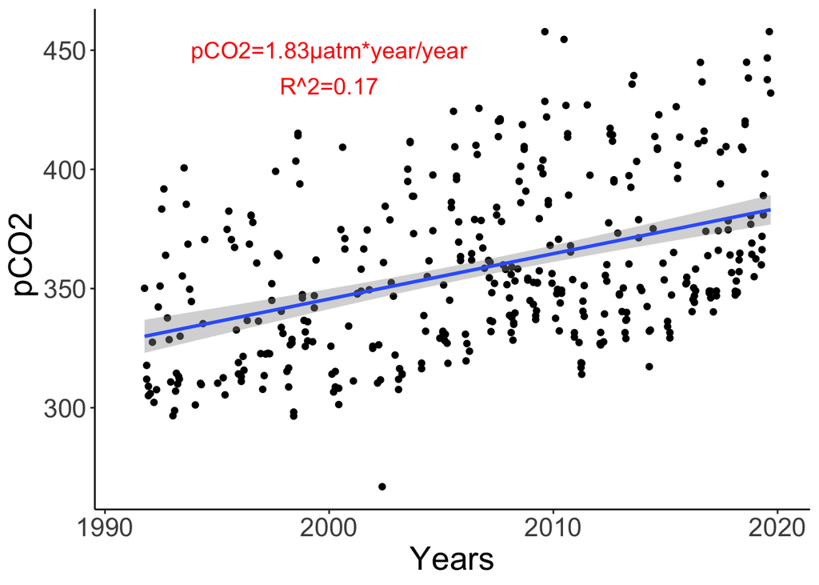

```r
bats_co2 %>%
  ggplot()+
  geom_point(mapping = aes(x=decy, y=pCO2))+
  geom_smooth(mapping = aes(x=decy, y=pCO2), method="lm")+
  ylab(" pCO2") +
  xlab("Years")+
  coord_cartesian(xlim = c(1991,2020))+
 annotate("text",x=2000, y= 435,label="R^2=0.17", size=5, color="red")+
   annotate("text",x=2000, y= 450,label="pCO2=1.83µatm*year/year", size=5, color="red")+
  theme(panel.grid.major = element_blank(),
        panel.grid.minor= element_blank(),
        panel.background = element_blank(), #removes annoying gray area
        axis.line= element_line(colour = "black"), #adds lines for the axes
        text = element_text(size = 20))
```

```r
pco2_model= with(bats_co2, lm(pCO2~I(decy-2000)))
```

```r
                                    data <- anova(pco2_model)
                                    knitr::kable(data,
                                               caption = "Anova for pCO2")
```

Anova for pCO2

|  | Df | Sum Sq | Mean Sq | F value | Pr(>F) |
| --- | --- | --- | --- | --- | --- |
| I(decy - 2000) | 1 | 88066.12 | 88066.116 | 83.94657 | 0 |
| Residuals | 385 | 403893.26 | 1049.073 | NA | NA |

Base on ANOVA results there is a significant difference of increasing pCO2 within the years. The p-value measure was 2.2e-16. The linear model has a positive increasing slope as consequence acidifying the seawater surface.

## 2) Is surface ocean seawater pH decreasing?

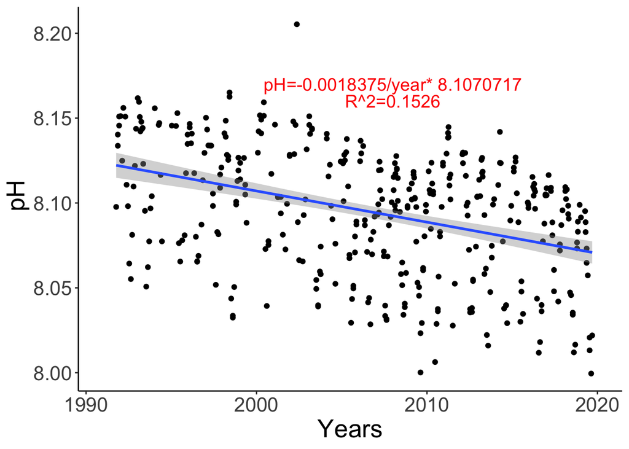

```r
  #PLOT
bats_co2 %>%
  ggplot()+
  geom_point(mapping = aes(x=decy, y=pH))+
  geom_smooth(mapping = aes(x=decy, y=pH), method="lm")+
    ylab(" pH") +
    xlab("Years")+
  coord_cartesian(xlim = c(1991,2020))+
   annotate("text",x=2008, y= 8.16,label="R^2=0.1526", size=5, color="red")+
   annotate("text",x=2008, y= 8.17,label="pH=-0.0018375/year* 8.1070717", size=5, color="red")+
    theme(panel.grid.major = element_blank(),
          panel.grid.minor= element_blank(),
          panel.background = element_blank(), #removes annoying gray area
          axis.line= element_line(colour = "black"), #adds lines for the axes
          text = element_text(size = 20))
```

```r
#How to cuantify if its increasing? statistics
pH_model= with(bats_co2, lm(pH~I(decy-2000)))
```

```r
 data <- anova(pH_model)
                          knitr::kable(data,
                                  caption = "Anova for pH")
```

Anova for pH

|  | Df | Sum Sq | Mean Sq | F value | Pr(>F) |
| --- | --- | --- | --- | --- | --- |
| I(decy - 2000) | 1 | 0.0821828 | 0.0821828 | 69.34893 | 0 |
| Residuals | 385 | 0.4562490 | 0.0011851 | NA | NA |

## 3a) Is surface ocean omega Aragonite decreasing?

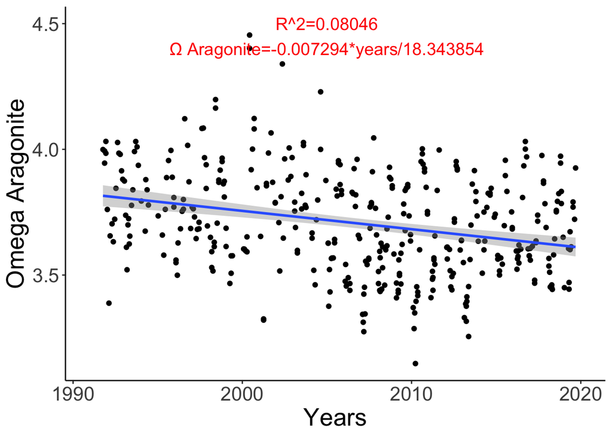

```r
#ARAGONITE
bats_co2 %>%
  ggplot()+
  geom_point(mapping = aes(x=decy, y=OmegaAragonite))+
  geom_smooth(mapping = aes(x=decy, y=OmegaAragonite), method="lm") +
  ylab("Omega Aragonite") +
  xlab("Years")+
   annotate("text",x=2005, y= 4.5,label="R^2=0.08046", size=5, color="red")+
   annotate("text",x=2005, y= 4.4,label="Ω Aragonite=-0.007294*years/18.343854", size=5, color="red")+
  coord_cartesian(xlim = c(1991,2020))+
  theme(panel.grid.major = element_blank(),
        panel.grid.minor= element_blank(),
        panel.background = element_blank(), #removes annoying gray area
        axis.line= element_line(colour = "black"), #adds lines for the axes
        text = element_text(size = 20))
```

```r
OmeAragonite_model= with(bats_co2, lm(OmegaAragonite~decy))
```

```r
 data <- anova(OmeAragonite_model)
                          knitr::kable(data,
                                  caption = "Anova for Omega Aragonite")
```

Anova for Omega Aragonite

|  | Df | Sum Sq | Mean Sq | F value | Pr(>F) |
| --- | --- | --- | --- | --- | --- |
| decy | 1 | 1.295075 | 1.2950747 | 33.68839 | 0 |
| Residuals | 385 | 14.800465 | 0.0384428 | NA | NA |

Base on ANOVA results there is a significance of decreasing on Omega Aragonite within the years. The p-value measure was 1.353e-08. It was expected that the model for omega Argonite to be negative decreasing linear model, connected to the decreasing pH sea water surface within the years dissolving calcium carbonate affecting directly calcium carbonate shells and skeletons.

## 3b) Is surface ocean omega Calcite decreasing?

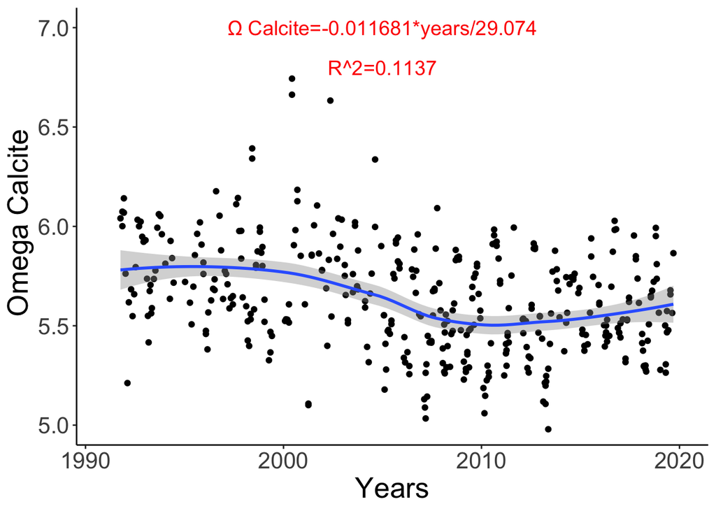

```r
#Calcite
bats_co2 %>%
  ggplot()+
  geom_point(mapping = aes(x=decy, y=OmegaCalcite))+
  geom_smooth(mapping = aes(x=decy, y=OmegaCalcite, method="lm")) +
  ylab(" Omega Calcite") +
  xlab("Years")+
  coord_cartesian(xlim = c(1991,2020), ylim = c(5,7))+
    annotate("text",x=2005, y= 6.8,label="R^2=0.1137", size=5, color="red")+
   annotate("text",x=2005, y= 7.0,label="Ω Calcite=-0.011681*years/29.074", size=5, color="red")+
  theme(panel.grid.major = element_blank(),
        panel.grid.minor= element_blank(),
        panel.background = element_blank(), #removes annoying gray area
        axis.line= element_line(colour = "black"), #adds lines for the axes
        text = element_text(size = 20))
```

```r
OmeCalcite_model= with(bats_co2, lm(OmegaCalcite~decy))
```

```r
 data <- anova(OmeCalcite_model)
                          knitr::kable(data,
                                  caption = "Anova for Omega Calcite")
```

Anova for Omega Calcite

|  | Df | Sum Sq | Mean Sq | F value | Pr(>F) |
| --- | --- | --- | --- | --- | --- |
| decy | 1 | 3.321194 | 3.3211935 | 49.38458 | 0 |
| Residuals | 385 | 25.891876 | 0.0672516 | NA | NA |

**Reference**

Janiszewska, K., Mazur, M., Machalski, M., & Stolarski, J. (2018). From pristine aragonite to blocky calcite: Exceptional preservation and diagenesis of cephalopod nacre in porous Cretaceous limestones. PloS one, 13(12), e0208598. https://doi.org/10.1371/journal.pone.0208598

Norzagaray-López, C. O., Hernández-Ayón, J. M., Calderon Aguilera, L. E., Reyes-Bonilla, H., Chapa-Balcorta, C., & Ayala-Bocos, A. (2017). Aragonite saturation and pH variation in a fringing reef are strongly influenced by oceanic conditions. Limnology and Oceanography, 62(6), 2375–2388. https://doi.org/10.1002/lno.10571

Rushe, G. J. and Heaton, . Pauline (2021, March 10). Bermuda. Encyclopedia Britannica. https://www.britannica.com/place/Bermuda